# rrda: Ridge Redundancy Analysis for High-Dimensional Omics Data

Hayato Yoshioka (University of Tokyo)

2025-10-02

# 1 Summary of R package **rrda** Workshop

This page is designed for a workshop on the R package **rrda** (Ridge Redundancy Analysis for High-Dimensional Omics Data), available on [CRAN](https://CRAN.R-project.org/package=rrda).

The **rrda** package is designed for analyzing **two matrices**, exploring how one may **influence or explain** the other.

While conventional methods of RDA (or RRDA) are restricted to relatively small matrices, **rrda** extends these computations to **high-dimensional data**—including datasets with more than **100,000 features**.

This capability makes it especially valuable in modern **omics sciences** and other fields where analyzing extremely large datasets is essential.

# 2 Algebra

## 2.1 Classic formula

The Ridge Redundancy Analysis model is represented as:

Let $Y$ be an $n \times q$ matrix of response variables, and let $X$ be an $n \times p$ matrix of predictor variables. We assume that the columns of matrices $Y$ and $X$ are centered to have means of 0.

The relation between $X$ and $Y$ is given by

$$Y = X B + E$$

where $B$ is the matrix of regression coefficients, and $E$ is an error matrix.

The ridge RDA aims to estimate $B$ under both rank and ridge restrictions. The corresponding optimization problem is

$$\hat{B}(\lambda, r) = \arg\min_B \left\{ \| Y - X B \|^2 + \lambda \| B
\|^2 \right\}
\quad \text{subject to} \quad \text{rank}(B) \leq r$$

where $\| A \|^2 = \text{tr}(A'A)$ is the Frobenius norm and $\lambda$ is the ridge regularization parameter.

## 2.2 For High-Dimensional Data

For Ridge Redundancy Analysis, the ridge estimator $\hat{B}(\lambda)$ can be decomposed as follows:

$$U_{\hat{B}(\lambda)} = V (D^{2} + \lambda I)^{-1/2}\hat{U}_{\lambda},
\quad
D_{\hat{B}(\lambda)} = \hat{D}_{\lambda}, \quad
V_{\hat{B}(\lambda)} = \hat{V}_{\lambda}$$

where the Singular Value Decomposition (SVD) of $X$ is
$$X = U D V^{\prime}$$
and $\hat{U}_{\lambda}, \hat{D}_{\lambda}, \hat{V}_{\lambda}$ are the SVD components of

$$M_\lambda = (D^{2} + \lambda I)^{-1/2} D U^{\prime} Y.$$

Since $M_\lambda$ depends on $\lambda$, its SVD must be computed for **each** value of $\lambda$.  
However, efficiency can be gained because $M_\lambda$ is the product of:

- a diagonal matrix $(D^{2} + \lambda I)^{-1/2}$, and
- a constant matrix $U'Y$ (independent of $\lambda$).

## 2.3 Final Expression

The rank-restricted ridge estimator is:

$$\hat{B}(\lambda,r) =
V(D^{2} + \lambda I)^{-1/2}
\hat{U}_{\lambda}^{[r]}
\hat{D}_{\lambda}^{[r]}
\hat{V}_{\lambda}^{[r]\prime}.$$

**Important Note 1:** Ridge Redundancy Analysis (RRDA) has **two parameters**:  
- **Ridge penalty $\lambda$** - **Rank $r$**

**Important Note 2:** RRDA is efficiently rewritten with **SVD of X**

# 3 Setup

Required packages

```r
pkgs <- c("rrda", "stringr")

# Install missing packages
to_install <- pkgs[!(pkgs %in% installed.packages()[, "Package"])]
if (length(to_install)) {
  install.packages(to_install, repos = "https://cloud.r-project.org")
}


op <- old.packages(repos = "https://cloud.r-project.org")
if (!is.null(op) && "rrda" %in% rownames(op)) {
  install.packages("rrda", repos = "https://cloud.r-project.org")
}


# load packages
library(rrda)
library(stringr)
```

# 4 Simulation

## 4.1 Data generation

Here we generate two matrices, **X** and **Y**, with a chosen rank constraint **k**.

```r
set.seed(10)
simdata<-rdasim1(n = 50,p = 100,q = 100,k = 5)
X <- simdata$X
Y <- simdata$Y
```

## 4.2 Parameter tuning

```r
cv_result<- rrda.cv(Y = Y, X = X,nfold = 5)
```

```
## Call:
## rrda.cv(Y = Y, X = X, lambda = 4.801 - 48010, maxrank = 15, nfold = 5)
```

```r
rrda.summary(cv_result = cv_result)
```

```
## === opt_min ===
## MSE:
## [1] 1.218769
## rank:
## [1] 5
## lambda:
## [1] 66.71
##
## === opt_lambda.1se ===
## MSE:
## [1] 1.244403
## rank:
## [1] 5
## lambda:
## [1] 248.7
##
## === opt_rank.1se ===
## MSE:
## [1] 1.218769
## rank:
## [1] 5
## lambda:
## [1] 66.71
```

## 4.3 Visualize Results

Here we illustrate the parameter tuning process (regularization path), which helps identify the optimal parameter for maximizing prediction accuracy from **X** to **Y**.

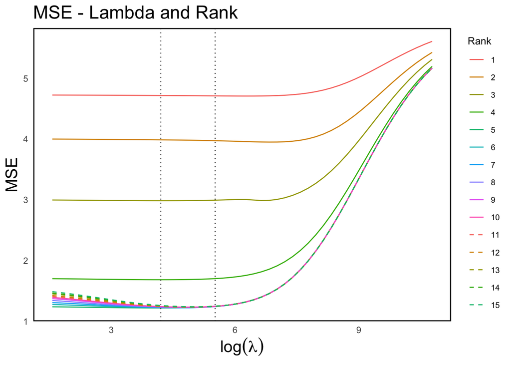

```r
p <- rrda.plot(cv_result) # cv result plot
print(p)
```

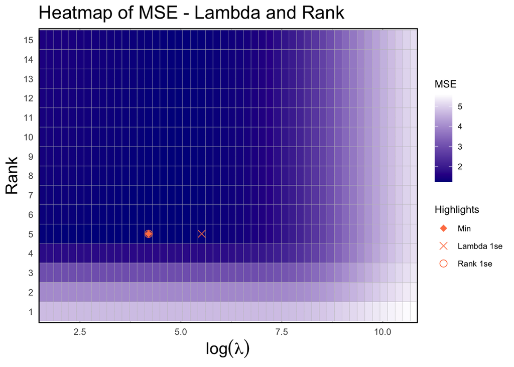

```r
h <- rrda.heatmap(cv_result) # cv result heatmap
print(h)
```

```r
best_lambda<-cv_result$opt_min$lambda  # selected parameter
best_rank<-cv_result$opt_min$rank # selected parameter

Bhat <- rrda.fit(Y = Y, X = X, nrank = best_rank,lambda = best_lambda) # fitting
Bhat_mat<-rrda.coef(Bhat)
```

```
## rank:
## [1] 5
## lambda:
## [1] 66.71
```

```r
Yhat_mat <- rrda.predict(Bhat = Bhat, X = X) # prediction
Yhat<-Yhat_mat[[1]][[1]][[1]] # predicted values

cor_Y_Yhat<-diag(cor(Y,Yhat)) # correlation
summary(cor_Y_Yhat)
```

```
##    Min. 1st Qu.  Median    Mean 3rd Qu.    Max.
##  0.4813  0.8754  0.9131  0.8964  0.9371  0.9813
```

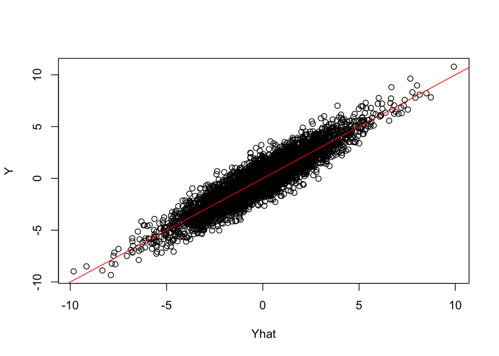

```r
plot(Yhat, Y)
abline(0, 1, col = "red")
```

## 4.4 Two-Dimensional Plot

Traditionally, (Ridge) RDA is visualized in **two dimensions**.  
However, in omics studies, this approach can sometimes **overload the plot** with information, making interpretation challenging.

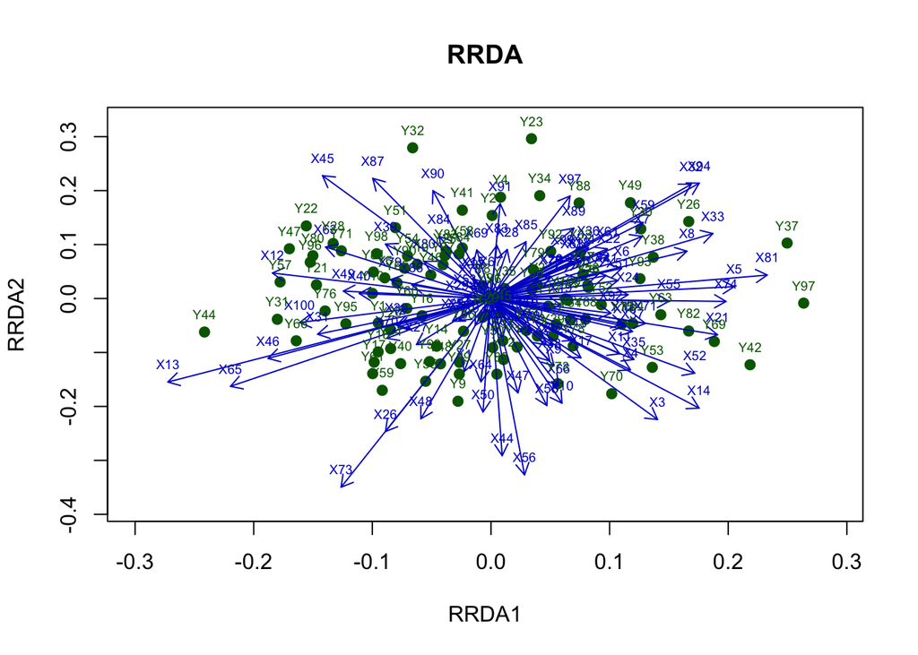

```r
# You want to specify one lambda in `rrda.fit` to visualize

ud<-Bhat$Bhat_comp[[1]][[1]] # SVD component of B (UD)
v <-Bhat$Bhat_comp[[1]][[2]] # SVD component of B (V)

ud12 <- ud[, 1:2]
v12 <- v[, 1:2]

# Base plot: ud (e.g., site scores)
plot(v12,
     xlab = "RRDA1", ylab = "RRDA2",
     xlim = range(c(ud12[,1], v12[,1])) * 1.1,
     ylim = range(c(ud12[,2], v12[,2])) * 1.1,
     pch = 19, col = "darkgreen",
     main = "RRDA")

# Add v (e.g., species scores) as arrows from origin
arrows(0, 0, ud12[,1], ud12[,2], col = "blue3", length = 0.1)

# Optionally add text labels
text(ud12, labels = paste0("X", 1:nrow(ud12)), pos = 3, col = "blue3", cex = 0.6)
text(v12, labels = paste0("Y", 1:nrow(v12)), pos = 3, col = "darkgreen", cex = 0.6)
```

## 4.5 Top Feature Heatmap

For better interpretability, we visualize the **feature–feature matrix** using a selected dimensionality, highlighting the most informative features.

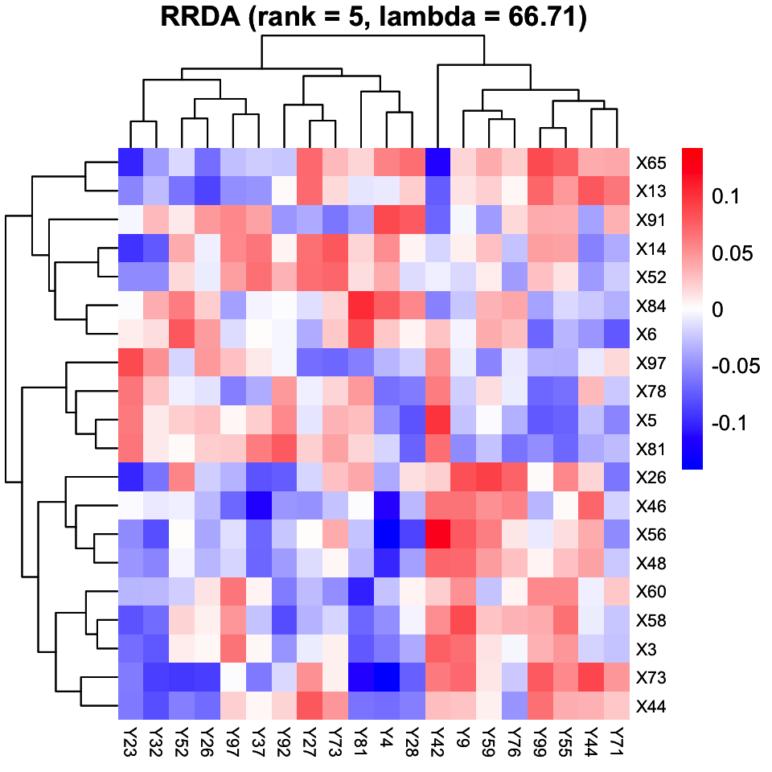

```r
best_lambda<-cv_result$opt_min$lambda
best_rank<-cv_result$opt_min$rank
rrda.top(Y=Y,X=X,nrank=best_rank,lambda=best_lambda,mx=20,my=20)
```

# 5 Application

As an application, we analyze **microbiome** and **metabolome** data from soybean grown under drought conditions.  
The dataset comes from a 2019 field experiment at Tottori University (Yoshioka et al. 2025).

## 5.1 Read data

Data is available on GitHub (`https://github.com/Yoska393/rrda/blob/main/RDAdata/SoyData.RDS`).

```r
#download from github
if(!dir.exists("RDAdata")) dir.create("RDAdata")
url <- "https://raw.githubusercontent.com/Yoska393/rrda/main/RDAdata/SoyData.RDS"
destfile <- "RDAdata/SoyData.RDS"

if (!file.exists(destfile)) {
  download.file(url, destfile, mode = "wb")
  message("✅ File downloaded successfully.")
}

SoyData <- readRDS("RDAdata/Soydata.RDS")

met <- SoyData$metabolome
micro <- SoyData$microbiome

metname<-substr(SoyData$metname, 1, 30)
microname<-str_extract(SoyData$microname, "(?<=o__)[^;]+(?=; f__)")

Y <- met
X <- micro

colnames(Y)<-metname
colnames(X)<-microname

dim(Y)
```

```
## [1] 179 253
```

```r
dim(X)
```

```
## [1]  179 4771
```

## 5.2 Parameter tuning

```r
cv_result<- rrda.cv(Y = Y, X = X, nfold = 5)
```

```
## Call:
## rrda.cv(Y = Y, X = X, lambda = 0.336 - 3360, maxrank = 15, nfold = 5)
```

```r
rrda.summary(cv_result = cv_result)
```

```
## === opt_min ===
## MSE:
## [1] 0.9410295
## rank:
## [1] 11
## lambda:
## [1] 241.8
##
## === opt_lambda.1se ===
## MSE:
## [1] 0.9561614
## rank:
## [1] 11
## lambda:
## [1] 3360
##
## === opt_rank.1se ===
## MSE:
## [1] 0.9798277
## rank:
## [1] 1
## lambda:
## [1] 241.8
```

## 5.3 Visualize Results

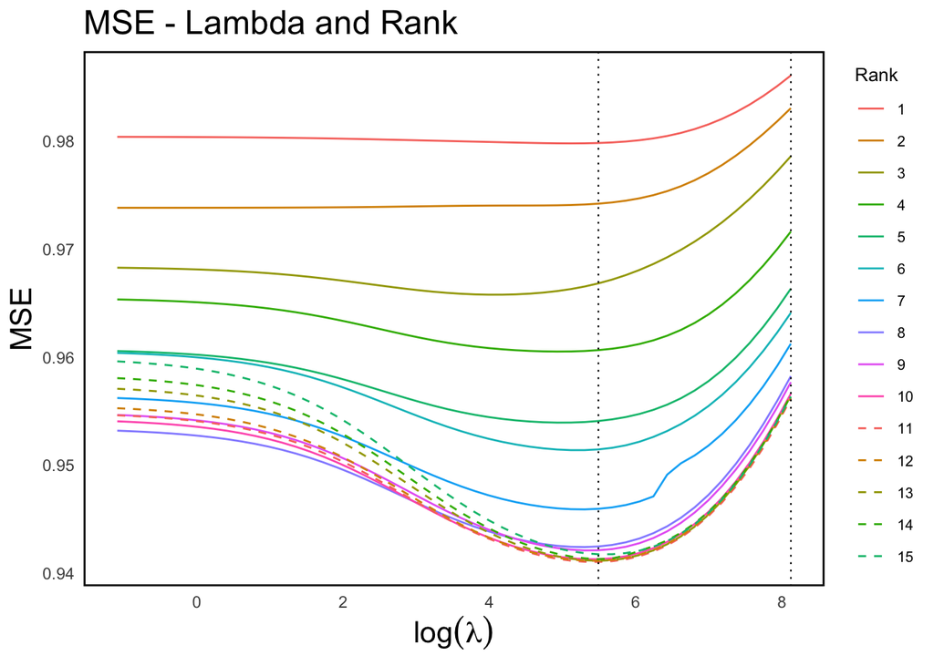

```r
p <- rrda.plot(cv_result) # cv result plot
print(p)
```

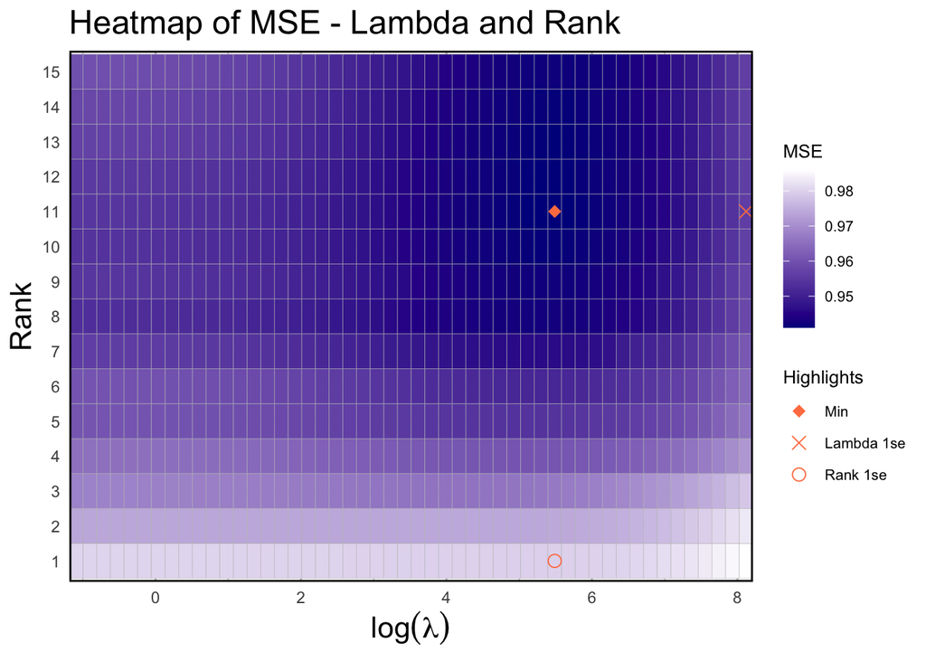

```r
h <- rrda.heatmap(cv_result) # cv result heatmap
print(h)
```

```r
best_lambda<-cv_result$opt_min$lambda  # selected parameter
best_rank<-cv_result$opt_min$rank # selected parameter

Bhat <- rrda.fit(Y = Y, X = X, nrank = best_rank,lambda = best_lambda)
```

## 5.4 Fitting

```r
# fitting
Bhat_mat<-rrda.coef(Bhat)
```

```
## rank:
## [1] 11
## lambda:
## [1] 241.8
```

```r
Yhat_mat <- rrda.predict(Bhat = Bhat, X = X) # prediction
Yhat<-Yhat_mat[[1]][[1]][[1]] # predicted values

cor_Y_Yhat<-diag(cor(Y,Yhat)) # correlation
summary(cor_Y_Yhat)
```

```
##    Min. 1st Qu.  Median    Mean 3rd Qu.    Max.
## 0.09661 0.50947 0.70204 0.66532 0.82641 0.97748
```

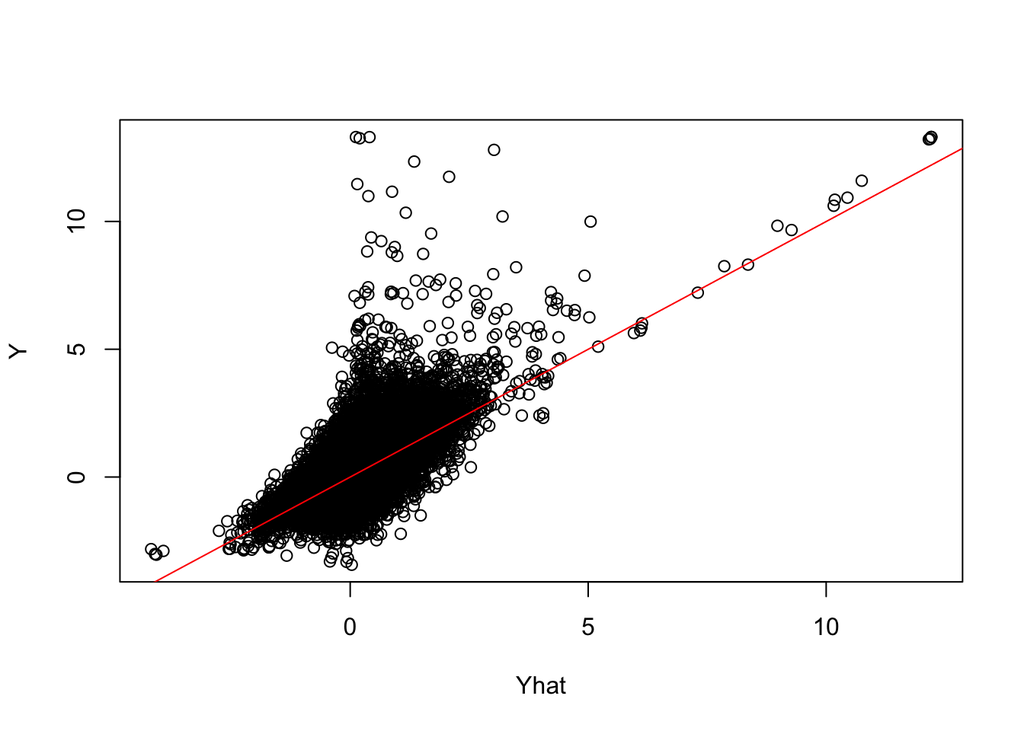

```r
plot(Yhat, Y)
abline(0, 1, col = "red")
```

## 5.5 Top Feature Heatmap

In the lower-dimensional space, we observe several **interesting interactions** among the top features.

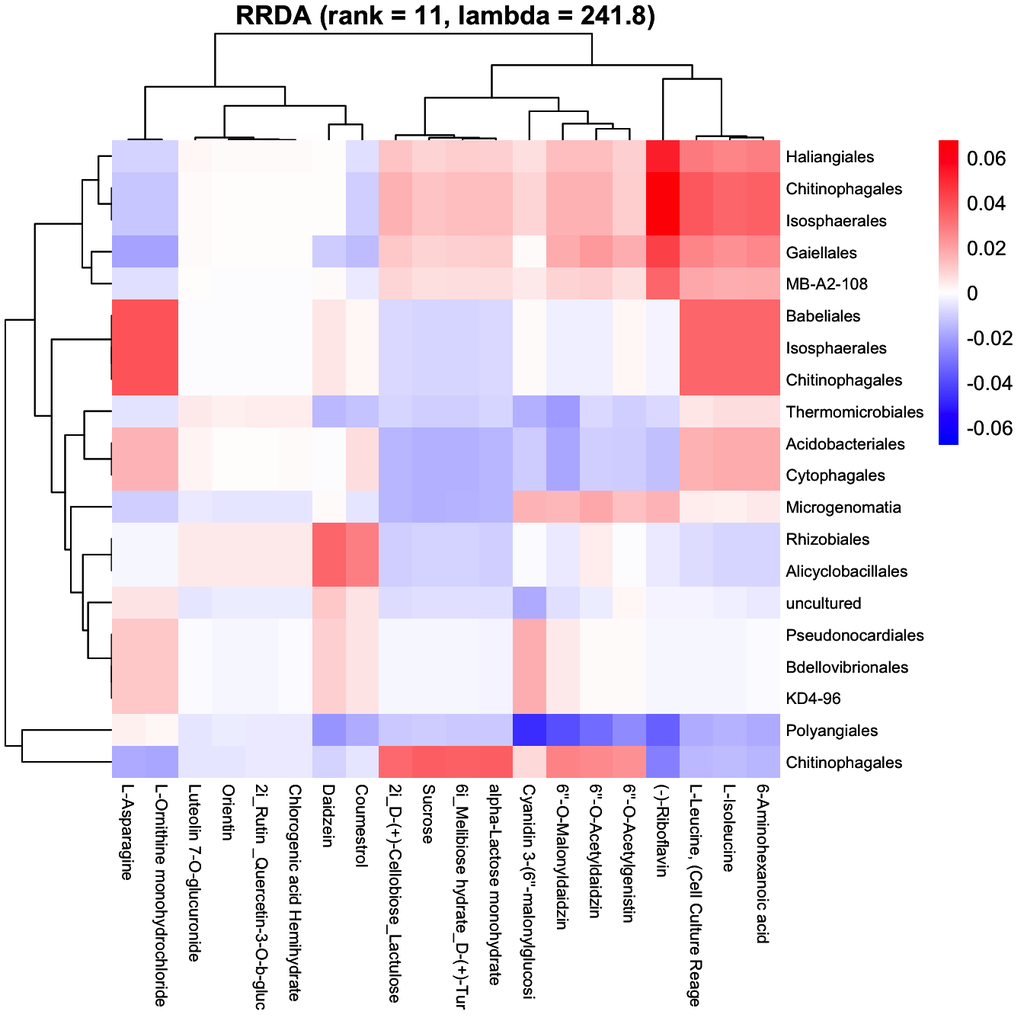

```r
best_lambda<-cv_result$opt_min$lambda  # selected parameter
best_rank<-cv_result$opt_min$rank # selected parameter
rrda.top(Y=Y,X=X,nrank=best_rank,lambda=best_lambda,mx=20,my=20)
```

# References

Yoshioka H, Aubert J, and Mary-Huard T (2025). rrda: Ridge Redundancy Analysis for High-Dimensional Omics Data. https://CRAN.R-project.org/package=rrda (CRAN R Package)

Yoshioka, H., Aubert, J., Iwata, H., and Mary-Huard, T., 2025. Ridge Redundancy Analysis for High-Dimensional Omics Data. bioRxiv, https://doi.org/10.1101/2025.04.16.649138